# act_report

## Report: act_report

- Create a **250-word-minimum written report** called "act_report.pdf" or "act_report.html" that communicates the insights and displays the visualization(s) produced from your wrangled data. This is to be framed as an external document, like a blog post or magazine article, for example.

## THE WERATEDOGS TWITTER DATA REPORT

WeRateDogs (@dog_rates) twitter handle is one dedicated to cheerfully rating any dog presented to it. The unque rating system shows the handle owners' love of dogs as no one dog is rated below 10/10. Hence, by their very existence, all dogs are a perfect 10/10 and most are even rated above that.

On approaching an analysis of the twitter data, particular care was taken to ensure the data presented was cleaned and tidied to reflect the handler's ratings appropriately and exude the passion and love of the dogs as shown. Hence, we worked on 3 data sets gathered from different methods to ensure a more thorough and accurate presentation of the information.

The first dataset, 'Enhanced Twitter Archive', was filtered for tweets that had ratings only. This was to ensure we remained focused on our goal of 'rating' the dogs.

The second dataset, 'Image Prediction File', served to support the primary WeRateDogs twitter data by introducing a means, via neural networks and machine learning, to predict-to some degree of accuracy-the breed of the dog. It further went on to tell us of the accuracy of its predictions with a confidence rating. As with the nature of the data, which could have been dirty and inaccurate, it went as far as to even tell us if the images presented were dogs to begin with.

The final dataset, 'Additional Data via the Twitter API', when gathered generated a huge chunk of untidy and dirty data, most of which were redundant to our goal. Hence, we primarily extracted the 'retweet count' and 'favorite count' information, which would assist us in our ratings.

These datasets once cleaned, tidied and re-purposed, were merged to produce a master dataset with accurate information related to dogs rated. Hence, we were easily able to identify a tweet, verify date and time tweet was created, the source, dog rating, dog stages, dog prediction, prediction accuracy, retweet and favorite counts.

```python
import pandas as pd
import matplotlib.pyplot as plt

import numpy as np

%matplotlib inline

twitter_archive_master_df = pd.read_csv('twitter_archive_master')
```

```python
twitter_archive_master_df['name'].iloc[0:10]
```

```
0    Phineas
1      Tilly
2     Archie
3      Darla
4     Cassie
5      Bruno
6       None
7        Jim
8    Jeffrey
9       None
Name: name, dtype: object
```

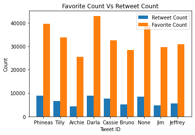

```python
X = twitter_archive_master_df['name'].iloc[0:9]
Y = twitter_archive_master_df['retweet_count'].iloc[0:9]
Z = twitter_archive_master_df['favorite_count'].iloc[0:9]

X_axis = np.arange(len(X))

plt.bar(X_axis - 0.2, Y, 0.4, label = 'Retweet Count')
plt.bar(X_axis + 0.2, Z, 0.4, label = 'Favorite Count')

plt.xticks(X_axis, X)
plt.xlabel("Tweet ID")
plt.ylabel("Count")
plt.title("Favorite Count Vs Retweet Count")
plt.legend()
plt.show()
```